# Course Schedulizer 2.0

https://cutt.ly/schedulizer

2026-10-06

## What is Course Schedulizer 2.0?

- A webapp for creating, editing, and viewing course schedules
- Complete rewrite of Course Schedulizer 1.0
  - Retains most of the features, much of the interface
  - Adds several new features (more later)
  - Not currently a student project

## Plan

1. Quick tour of important features (What, now how)
2. BTS with Jenna Hunt
3. But can it _____ ?
4. Live demo (watch or follow along)
5. Try it on your own department schedule
   - Make progress or just try out features
   - See if you can break anything
   - Let me know how it could be better

## Where is Course Schedulizer?

https://schedulizer.pruim.co

[figure not shown]

## Schedulizer is a web app

- It runs in your browser. There is no backend database or storage.
- If you browser cache is cleared or overflows or you switch browsers, you will not have your data, unless
- You have exported it (download a file or save on OneDrive).

# Quick Tour

## Department View

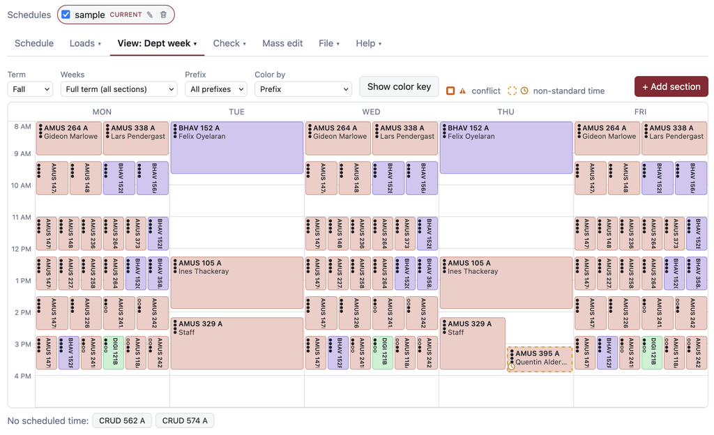

## Faculty View

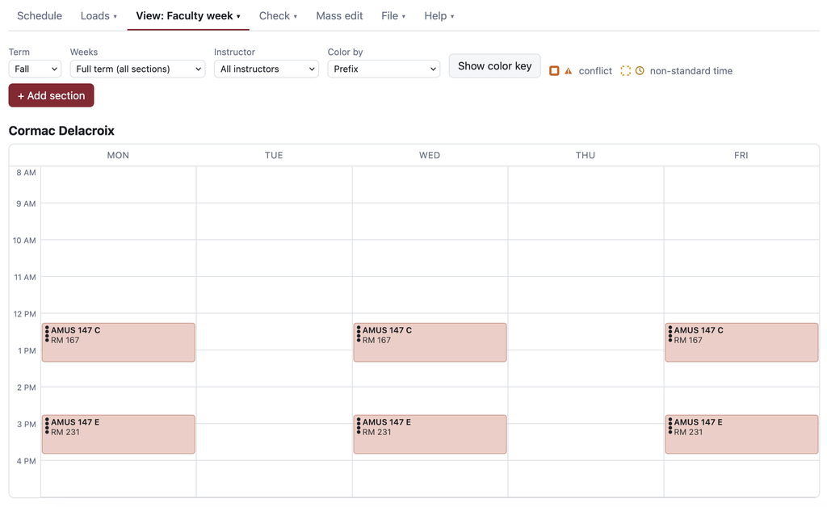

## Room View

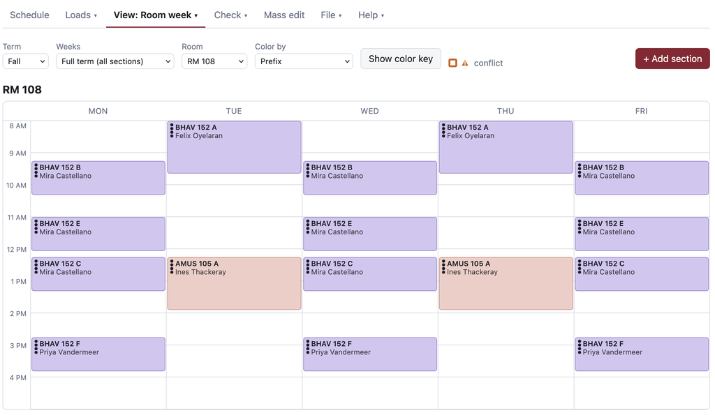

## (Teaching) Loads View

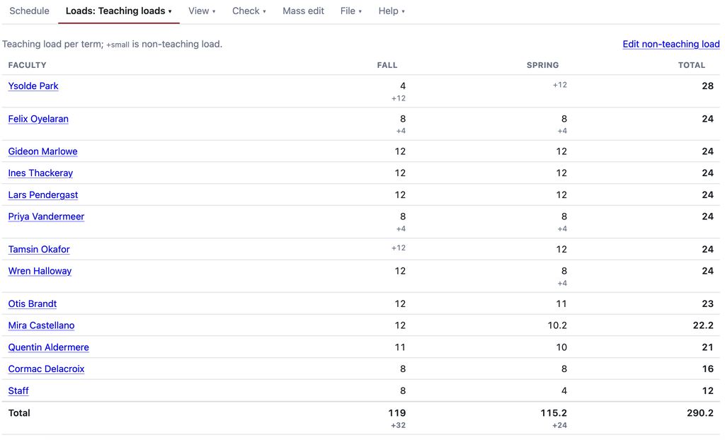

## Creating/Updating Sections

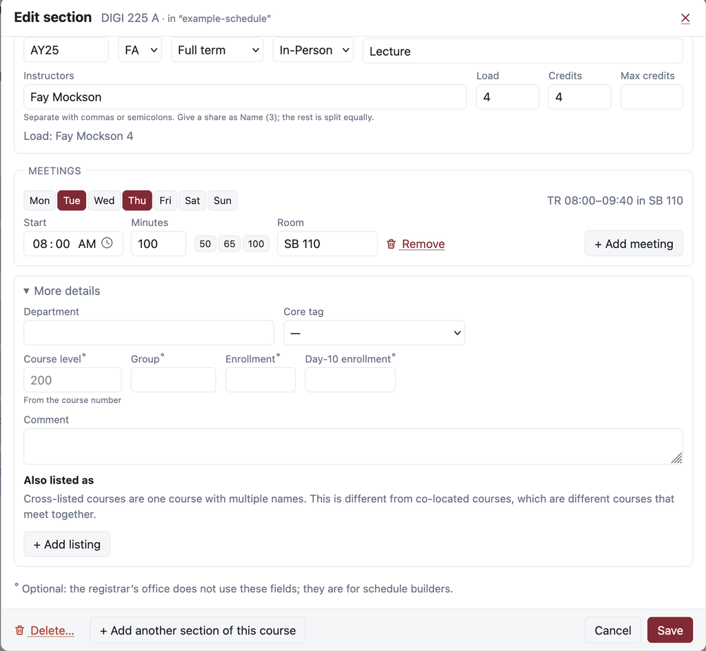

## Conflicts & Custom Constraints

See which of your scheduled courses conflicts with another course or a constraint rule.

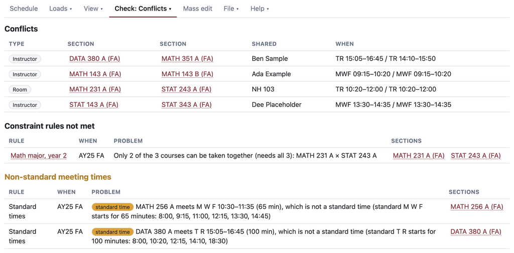

## Conflicts in the the section editor

Conflicts also appear at the bottom of the section editor and update live as you enter information.

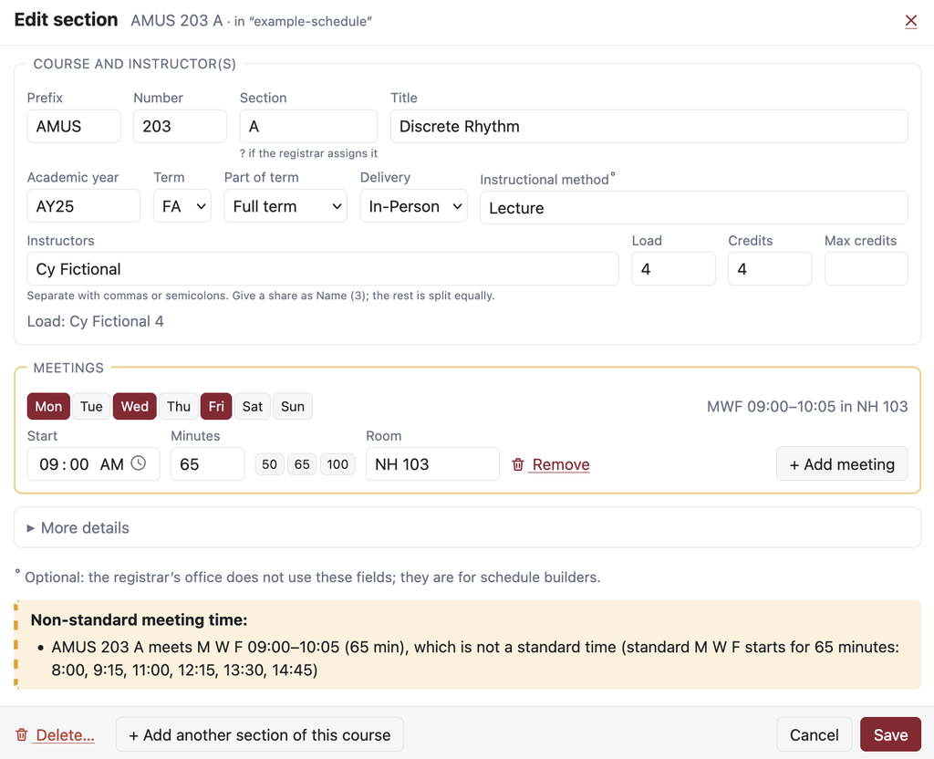

## Constraint Rules

You can add or remove constraints by creating constraint rules.

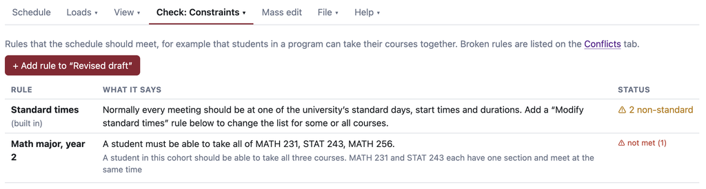

## Compare Schedules

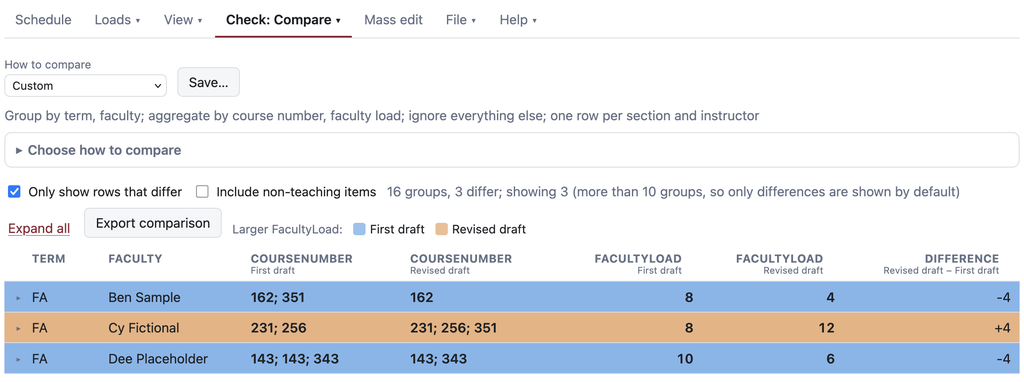

## Mass Edits

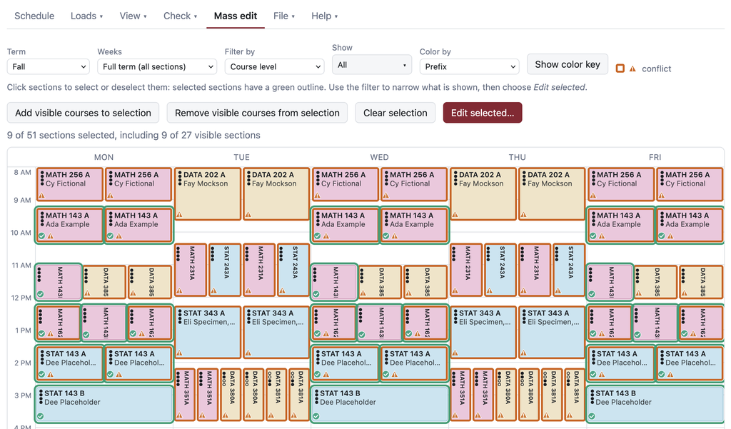

## Cross-listed courses (and and tags) officially supported

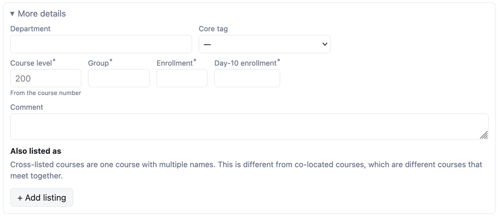

## Connect directly to OneDrive

Schedulizer can read/write from/to OneDrive.

- Provides a way to share your schedule with others.

## Issues

- **Use the Comment field** to communicate to your dean and Student Success if you can’t get Course Schedulizer to do exactly what you want.

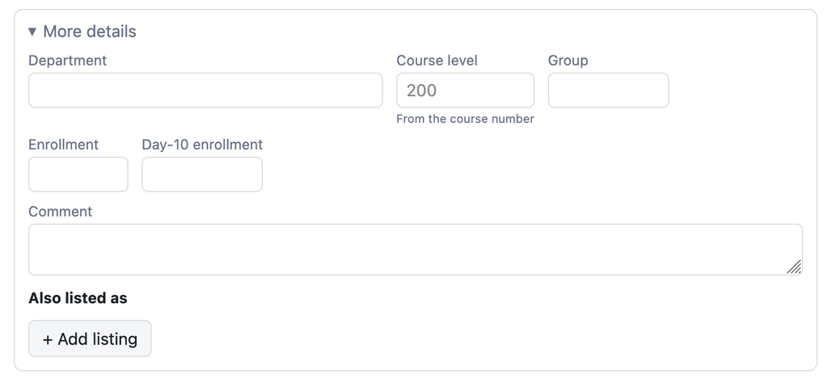

- **Bugs?** Email rpruim@gmail.com
- **Feature requests?** Email rpruim@gmail.com

# BTS with Jenna

# But can it _____ ?

## Yes, but can Schedulizer _____ ?

#### **You**: Fill in the blank.

#### **I’ll** answer briefly

- Yes
- No
- I don’t know
- Stay tuned (it’s in the demo)
- Etc.

# Live Demo

## Where is Course Schedulizer?

https://schedulizer.pruim.co

[figure not shown]

## Outline of the Schedulizer workflow

1. **Import** one or more schedules.
2. **Look** over your schedule using one of the calendar views.
3. **Change** what needs changing.
4. **Check** your schedule by examining loads, investigating conflicts, or comparing schedules.
5. **Export** to Excel to save your work for next time or so you can send it.

## 0. Getting Help

- **Help > User guide**

## 1. **Import** an example schedule

Choose **Example schedule**

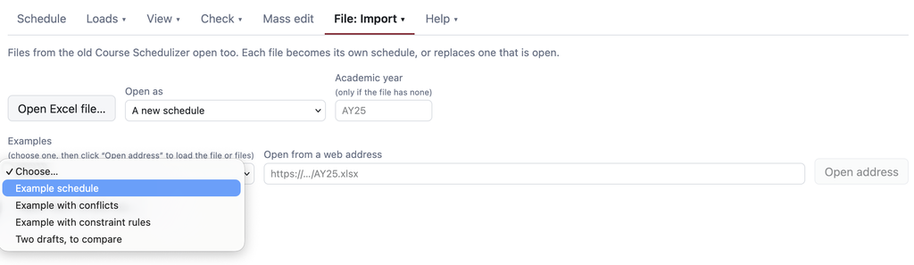

## 2. **Look** over your schedule

1. Find a section that only meets for half of the semester.
2. Find a section that meets in the evening.
3. Color the schedule by instructor and pull up the color key.

## 3. **Change** what needs changing.

1. Change the academic year from AY25 to AY26 for all sections. (Mass edit)
2. Change the name of one of the instructors. (Mass edit)
3. Move a section to a different time and/or room?
   - Did your change introduce a conflict?
4. Add a new section to the schedule.
5. Change the nickname of your schedule from sample to something else.

## 4. **Check** your schedule.

1. Which instructor has the heaviest/lightest load? (Loads: Teaching Load)
2. How many faculty are on sabbatical? (Loads: Non-teaching Load)
3. Does the schedule have any conflicts? (Check: Conflicts)

## 4. **Check** your schedule.

1. **Import a new example:** “two drafts, to compare”
   - uncheck any schedules other than these two
   - re-order them if you like
2. Go to **Check: Compare**
3. Try several of the **built-in comparisons.**
4. For the adventurous: **Create a custom comparison.**

## 5. **Export** to Excel

**File: Meta** has some options for how file names are determined and other information about the schedule as a whole

1. Add some notes about your schedule.

**File: Export** is where you do the actual export.

2. Export your schedule (download or save to OneDrive)

**Caution**

You can, but probably should not, edit the Excel file.

# Working on your own schedule

## Where is Course Schedulizer?

https://schedulizer.pruim.co

[figure not shown]